# HW_3_Alexander_Niculescu

Test Name: test2 1. The weights of steers in a herd are distributed normally. The variance is 40,000 and the mean steer weight is 1300 lbs. Find the probability that the weight of a randomly selected steer is greater than 979 lbs. (Round your answer to 4 decimal places)

```r
#f(x|μ, σ^2)
round(pnorm(q=979, mean=1300, sd=sqrt(40000), lower.tail = FALSE), 4)
```

```
## [1] 0.9458
```

2. SVGA monitors manufactured by TSI Electronics have life spans that have a normal distribution with a variance of 1,960,000 and a mean life span of 11,000 hours. If a SVGA monitor is selected at random, find the probability that the life span of the monitor will be more than 8340 hours. (Round your answer to 4 decimal places)

```r
round(pnorm(q=8340, mean=11000, sd=sqrt(1960000), lower.tail = FALSE), 4)
```

```
## [1] 0.9713
```

3. Suppose the mean income of firms in the industry for a year is 80 million dollars with a standard deviation of 3 million dollars. If incomes for the industry are distributed normally, what is the probability that a randomly selected firm will earn between 83 and 85 million dollars? (Round your answer to 4 decimal places)

```r
round(pnorm(q=85, mean=80, sd=(3), lower.tail = TRUE)-pnorm(q=83, mean=80, sd=(3), lower.tail = TRUE), 4)
```

```
## [1] 0.1109
```

4. Suppose GRE Verbal scores are normally distributed with a mean of 456 and a standard deviation of 123. A university plans to offer tutoring jobs to students whose scores are in the top 14%. What is the minimum score required for the job offer? Round your answer to the nearest whole number, if necessary.

```r
round(qnorm(p=.14, mean=456, sd=123, lower.tail = FALSE), 0)
```

```
## [1] 589
```

5. The lengths of nails produced in a factory are normally distributed with a mean of 6.13 centimeters and a standard deviation of 0.06 centimeters. Find the two lengths that separate the top 7% and the bottom 7%. These lengths could serve as limits used to identify which nails should be rejected. Round your answer to the nearest hundredth, if necessary.

```r
round(qnorm(p=.07, mean=6.13, sd=.06, lower.tail = TRUE), 2)
```

```
## [1] 6.04
```

```r
round(qnorm(p=.07, mean=6.13, sd=.06, lower.tail= FALSE), 2)
```

```
## [1] 6.22
```

6. An English professor assigns letter grades on a test according to the following scheme.

A: Top 13% of scores B: Scores below the top 13% and above the bottom 55% C: Scores below the top 45% and above the bottom 20% D: Scores below the top 80% and above the bottom 9% F: Bottom 9% of scores Scores on the test are normally distributed with a mean of 78.8 and a standard deviation of 9.8. Find the numerical limits for a C grade. Round your answers to the nearest whole number, if necessary.

```r
#C grade is between .20 and .45
round(qnorm(p=.20, mean=78.8, sd=9.8, lower.tail = TRUE), 0)
```

```
## [1] 71
```

```r
round(qnorm(p=.45, mean=78.8, sd=9.8, lower.tail= FALSE), 0)
```

```
## [1] 80
```

7. Suppose ACT Composite scores are normally distributed with a mean of 21.2 and a standard deviation of 5.4. A university plans to admit students whose scores are in the top 45%. What is the minimum score required for admission? Round your answer to the nearest tenth, if necessary.

```r
round(qnorm(p=.45, mean=21.2, sd=5.4, lower.tail = FALSE), 1)
```

```
## [1] 21.9
```

8. Consider the probability that less than 11 out of 151 students will not graduate on time. Assume the probability that a given student will not graduate on time is 9%. Approximate the probability using the normal distribution. (Round your answer to 4 decimal places.)

```r
#pbinom threshold
round(pbinom(10, size=151, prob=0.09), 4)
```

```
## [1] 0.192
```

9. The mean lifetime of a tire is 48 months with a standard deviation of 7. If 147 tires are sampled, what is the probability that the mean of the sample would be greater than 48.83 months? (Round your answer to 4 decimal places)

```r
sem<- (7)/sqrt((147))

round(pnorm(q=48.83, mean=48, sd=sem, lower.tail = FALSE), 4)
```

```
## [1] 0.0753
```

10. The quality control manager at a computer manufacturing company believes that the mean life of a computer is 91 months, with a standard deviation of 10. If he is correct, what is the probability that the mean of a sample of 68 computers would be greater than 93.54 months? (Round your answer to 4 decimal places)

```r
#(10, 68)
sem<- (10)/sqrt((68))

round(pnorm(q=93.54, mean=91, sd=sem, lower.tail = FALSE), 4)
```

```
## [1] 0.0181
```

11. A director of reservations believes that 7% of the ticketed passengers are no-shows. If the director is right, what is the probability that the proportion of no-shows in a sample of 540 ticketed passengers would differ from the population proportion by less than 3%? (Round your answer to 4 decimal places)

```r
round(pnorm(.04, .07, sqrt(.07*(1-.07)/540), lower.tail = FALSE) - pnorm(.27, .23, sqrt(.07*(1-.07)/540), lower.tail = FALSE), 4)
```

```
## [1] 0.9967
```

12. A bottle maker believes that 23% of his bottles are defective. If the bottle maker is accurate, what is the probability that the proportion of defective bottles in a sample of 602 bottles would differ from the population proportion by greater than 4%? (Round your answer to 4 decimal places)

```r
round(pnorm(.23-.04, .23, sqrt(.23*(1-.23)/602), lower.tail = TRUE) + pnorm(.27, .23, sqrt(.23*(1-.23)/602), lower.tail = FALSE), 4)
```

```
## [1] 0.0197
```

13. A research company desires to know the mean consumption of beef per week among males over age 48. Suppose a sample of size 208 is drawn with 𝑥𝑥̅ = 3.9. Assume å = 0.8 . Construct the 80% confidence interval for the mean number of lb. of beef per week among males over 48. (Round your answers to 1 decimal place)

```r
pval <- p(.8)
t <- qt(pval, 207)

lower <- (3.9 + t *  .8 / sqrt(208))
upper <- (3.9 - t *  .8 / sqrt(208))

round(lower, 1)
```

```
## [1] 3.8
```

```r
round(upper, 1)
```

```
## [1] 4
```

14. An economist wants to estimate the mean per capita income (in thousands of dollars) in a major city in California. Suppose a sample of size 7472 is drawn with 𝑥𝑥̅ = 16.6. Assume å = 11 . Construct the 98% confidence interval for the mean per capita income. (Round your answers to 1 decimal place)

```r
pval <- p(.98)
t <- qt(pval, 7471)

upper <- (16.6 - t *  11 / sqrt(7472))

lower <- (16.6 + t *  11 / sqrt(7472))

round(lower, 1)
```

```
## [1] 16.3
```

```r
round(upper, 1)
```

```
## [1] 16.9
```

15. Find the value of t such that 0.05 of the area under the curve is to the left of t. Assume the degrees of freedom equals 26.

```r
#Step 1. Choose the picture which best describes the problem.
#top right

#Step 2. Write your answer below.
round(qt(.05, df=26, lower.tail = FALSE), 4)
```

```
## [1] 1.7056
```

16. The following measurements ( in picocuries per liter ) were recorded by a set of helium gas detectors installed in a laboratory facility: 383.6, 347.1, 371.9, 347.6, 325.8, 337. Using these measurements, construct a 90% confidence interval for the mean level of helium gas present in the facility. Assume the population is normally distributed.

```r
sem <- function(sd, n) {
    return(sd/sqrt(n))
}
#Step 1. Calculate the sample mean for the given sample data. (Round answer to 2 decimal places)
df <- c(383.6, 347.1, 371.9, 347.6, 325.8, 337)
elements <- 6
x <- mean(df)
round(mean(df), 2)
```

```
## [1] 352.17
```

```r
#Step 2. Calculate the sample standard deviation for the given sample data. (Round answer to 2 decimal places)
sd <- sd(df)
round(sd(df), 2)
```

```
## [1] 21.68
```

```r
#Step 3. Find the critical value that should be used in constructing the confidence interval. (Round answer to 3 decimal places)
cv <- qt((1-(1-.9)/2), 5)
round(cv, 3)
```

```
## [1] 2.015
```

```r
#Step 4. Construct the 90% confidence interval. (Round answer to 2 decimal places)
se <- sem(sd, 5)
se
```

```
## [1] 9.693737
```

```r
#Lower Bound:
round(x - (cv*se), 2)
```

```
## [1] 332.63
```

```r
#Upper Bound:
round(x + (cv*se), 2)
```

```
## [1] 371.7
```

17. A random sample of 16 fields of spring wheat has a mean yield of 46.4 bushels per acre and standard deviation of 2.45 bushels per acre. Determine the 80% confidence interval for the true mean yield. Assume the population is normally distributed.

```r
#Step 1. Find the critical value that should be used in constructing the confidence interval. (Round answer to 3 decimal places)
#qt(p, df, ncp, lower.tail = TRUE, log.p = FALSE)

qtfx <- qt((1-.80)/2, 15, lower.tail = FALSE)
round(qtfx, 3)
```

```
## [1] 1.341
```

```r
#Step 2. Construct the 80% confidence interval. (Round answer to 1 decimal place)
round(46.4 + (qtfx * 2.45)/sqrt(16), 1)
```

```
## [1] 47.2
```

```r
round(46.4 - (qtfx * 2.45)/sqrt(16), 1)
```

```
## [1] 45.6
```

18. A toy manufacturer wants to know how many new toys children buy each year. She thinks the mean is 8 toys per year. Assume a previous study found the standard deviation to be 1.9. How large of a sample would be required in order to estimate the mean number of toys bought per child at the 99% confidence level with an error of at most 0.13 toys? (Round your answer up to the next integer)

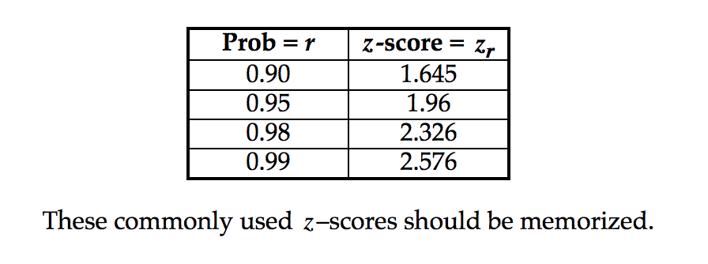

fig. 1

```r
##z = x-mu/delta
sd <- 1.9
e <- 0.13

#why is qnorm not equivalent to the z table
round(((qnorm(.995)*sd)/e)^2, 0)
```

```
## [1] 1417
```

19. A research scientist wants to know how many times per hour a certain strand of bacteria reproduces. He believes that the mean is 12.6. Assume the variance is known to be 3.61. How large of a sample would be required in order to estimate the mean number of reproductions per hour at the 95% confidence level with an error of at most 0.19 reproductions? (Round your answer up to the next integer)

```r
#used z table again for 1.96
#qnorm(.975)
z <- 1.96
round(((z*sqrt(3.61))/.19)^2)
```

```
## [1] 384
```

20. The state education commission wants to estimate the fraction of tenth grade students that have reading skills at or below the eighth grade level.

```r
#Step 1. Suppose a sample of 2089 tenth graders is drawn. Of the students sampled, 1734 read above the eighth grade level.
#Using the data, estimate the proportion of tenth graders reading at or below the eighth grade level. (Write your answer as a fraction or a decimal number rounded to 3 decimal places)
prop <- 1-1734/2089
round(prop, 3)
```

```
## [1] 0.17
```

```r
#Step 2. Suppose a sample of 2089 tenth graders is drawn. Of the students sampled, 1734 read above the eighth grade level.
#Using the data, construct the 98% confidence interval for the population proportion of tenth graders reading at or below the eighth grade level. (Round your answers to 3 decimal places)

#using the z value for 98%
z <- 2.326
SE <- sqrt((prop * (1-prop))/2089)

lower <- round(prop - z * (SE)- 05./2089, 3)
upper <- round(prop + z * (SE)- 05./2089, 3)
lower
```

```
## [1] 0.148
```

```r
upper
```

```
## [1] 0.187
```

21. An environmentalist wants to find out the fraction of oil tankers that have spills each month.

```r
#Step 1. Suppose a sample of 474 tankers is drawn. Of these ships, 156 had spills. Using the data, estimate the proportion of oil tankers that had spills. (Write your answer as a fraction or a decimal number rounded to 3 decimal places)
prop <- 156/474
round(prop, 3)
```

```
## [1] 0.329
```

```r
#Step 2. Suppose a sample of 474 tankers is drawn. Of these ships, 156 had spills. Using the data, construct the 95% confidence interval for the population proportion of oil tankers that have spills each month. (Round your answers to 3 decimal places)
z <- 1.96
SE <- sqrt((prop * (1-prop))/474)

lower <- round(prop - z * (SE)- 05./474, 3)
upper <- round(prop + z * (SE)- 05./474, 3)

lower
```

```
## [1] 0.276
```

```r
upper
```

```
## [1] 0.361
```